# New tidyr verbs demo

Pierrette Lo

12/10/2019

> This tutorial is based on: https://swcarpentry.github.io/r-novice-gapminder/14-tidyr/

### Getting started

Load up the tidyverse:

```r
library(tidyverse)
```

Read in a “wide” version of the Gapminder socioeconomic dataset from the Software Carpentries website:

```r
gap_wide <- read_csv("https://raw.githubusercontent.com/swcarpentry/r-novice-gapminder/gh-pages/_episodes_rmd/data/gapminder_wide.csv")
```

Check out the column names and the first few rows of `gap_wide`.

```r
colnames(gap_wide)
```

```
##  [1] "continent"      "country"        "gdpPercap_1952" "gdpPercap_1957"
##  [5] "gdpPercap_1962" "gdpPercap_1967" "gdpPercap_1972" "gdpPercap_1977"
##  [9] "gdpPercap_1982" "gdpPercap_1987" "gdpPercap_1992" "gdpPercap_1997"
## [13] "gdpPercap_2002" "gdpPercap_2007" "lifeExp_1952"   "lifeExp_1957"
## [17] "lifeExp_1962"   "lifeExp_1967"   "lifeExp_1972"   "lifeExp_1977"
## [21] "lifeExp_1982"   "lifeExp_1987"   "lifeExp_1992"   "lifeExp_1997"
## [25] "lifeExp_2002"   "lifeExp_2007"   "pop_1952"       "pop_1957"
## [29] "pop_1962"       "pop_1967"       "pop_1972"       "pop_1977"
## [33] "pop_1982"       "pop_1987"       "pop_1992"       "pop_1997"
## [37] "pop_2002"       "pop_2007"
```

```r
head(gap_wide)
```

```
## # A tibble: 6 x 38
##   continent country gdpPercap_1952 gdpPercap_1957 gdpPercap_1962
##   <chr>     <chr>            <dbl>          <dbl>          <dbl>
## 1 Africa    Algeria          2449.          3014.          2551.
## 2 Africa    Angola           3521.          3828.          4269.
## 3 Africa    Benin            1063.           960.           949.
## 4 Africa    Botswa~           851.           918.           984.
## 5 Africa    Burkin~           543.           617.           723.
## 6 Africa    Burundi           339.           380.           355.
## # ... with 33 more variables: gdpPercap_1967 <dbl>, gdpPercap_1972 <dbl>,
## #   gdpPercap_1977 <dbl>, gdpPercap_1982 <dbl>, gdpPercap_1987 <dbl>,
## #   gdpPercap_1992 <dbl>, gdpPercap_1997 <dbl>, gdpPercap_2002 <dbl>,
## #   gdpPercap_2007 <dbl>, lifeExp_1952 <dbl>, lifeExp_1957 <dbl>,
## #   lifeExp_1962 <dbl>, lifeExp_1967 <dbl>, lifeExp_1972 <dbl>,
## #   lifeExp_1977 <dbl>, lifeExp_1982 <dbl>, lifeExp_1987 <dbl>,
## #   lifeExp_1992 <dbl>, lifeExp_1997 <dbl>, lifeExp_2002 <dbl>,
## #   lifeExp_2007 <dbl>, pop_1952 <dbl>, pop_1957 <dbl>, pop_1962 <dbl>,
## #   pop_1967 <dbl>, pop_1972 <dbl>, pop_1977 <dbl>, pop_1982 <dbl>,
## #   pop_1987 <dbl>, pop_1992 <dbl>, pop_1997 <dbl>, pop_2002 <dbl>,
## #   pop_2007 <dbl>
```

Notice that there is data in the column names (i.e. years), so this is not a “tidy” dataset. If we want to do any plotting or analysis, we will likely need to convert the data from “wide” to “long” format.

### From wide to long: `pivot_longer()` (formerly known as `gather()`)

Here are some helpful diagrams from the original tutorial, depicting our wide data and the steps to make it long.

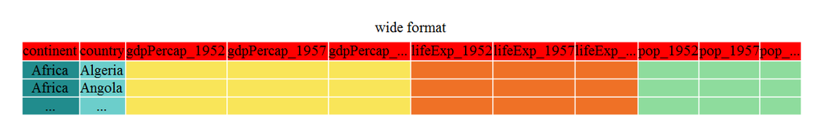

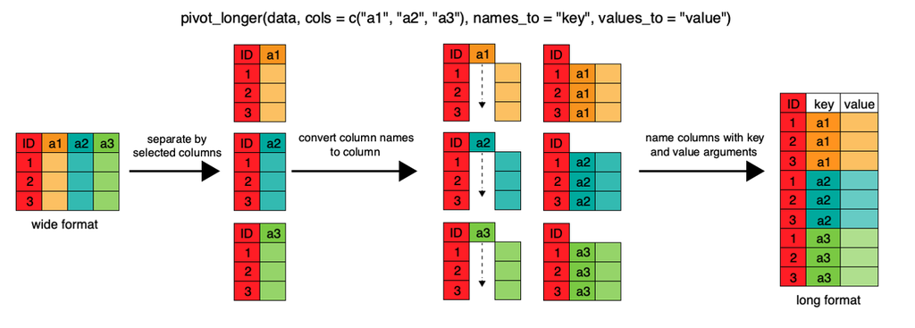

The new pivot_longer() includes functions to gather and separate multiple columns in a single command. Previously this would have required multiple iterations of `gather()` and `separate()`.

There are 3 types of observations in this dataset: gdpPercap, lifeExp, and pop.

Here’s how you would lengthen this dataframe the old way:

```r
gap_wide %>%
  gather(c(-continent, -country),
         key = "obstype_year",
         value = "value")
```

```
## # A tibble: 5,112 x 4
##    continent country                  obstype_year   value
##    <chr>     <chr>                    <chr>          <dbl>
##  1 Africa    Algeria                  gdpPercap_1952 2449.
##  2 Africa    Angola                   gdpPercap_1952 3521.
##  3 Africa    Benin                    gdpPercap_1952 1063.
##  4 Africa    Botswana                 gdpPercap_1952  851.
##  5 Africa    Burkina Faso             gdpPercap_1952  543.
##  6 Africa    Burundi                  gdpPercap_1952  339.
##  7 Africa    Cameroon                 gdpPercap_1952 1173.
##  8 Africa    Central African Republic gdpPercap_1952 1071.
##  9 Africa    Chad                     gdpPercap_1952 1179.
## 10 Africa    Comoros                  gdpPercap_1952 1103.
## # ... with 5,102 more rows
```

And here it is using the new way:

```r
gap_wide %>%
  pivot_longer(cols = c(-continent, -country),
               names_to = "obstype_year",
               values_to = "value")
```

```
## # A tibble: 5,112 x 4
##    continent country obstype_year   value
##    <chr>     <chr>   <chr>          <dbl>
##  1 Africa    Algeria gdpPercap_1952 2449.
##  2 Africa    Algeria gdpPercap_1957 3014.
##  3 Africa    Algeria gdpPercap_1962 2551.
##  4 Africa    Algeria gdpPercap_1967 3247.
##  5 Africa    Algeria gdpPercap_1972 4183.
##  6 Africa    Algeria gdpPercap_1977 4910.
##  7 Africa    Algeria gdpPercap_1982 5745.
##  8 Africa    Algeria gdpPercap_1987 5681.
##  9 Africa    Algeria gdpPercap_1992 5023.
## 10 Africa    Algeria gdpPercap_1997 4797.
## # ... with 5,102 more rows
```

Notice that the obstype_year column still contains two pieces of information.

Here’s how we would have separated that column into two using the old method:

```r
gap_wide %>%
  gather(c(-continent, -country),
         key = "obstype_year",
         value = "value") %>%
  separate(obstype_year,
           into = c("obstype", "year"),
           sep = "_")
```

```
## # A tibble: 5,112 x 5
##    continent country                  obstype   year  value
##    <chr>     <chr>                    <chr>     <chr> <dbl>
##  1 Africa    Algeria                  gdpPercap 1952  2449.
##  2 Africa    Angola                   gdpPercap 1952  3521.
##  3 Africa    Benin                    gdpPercap 1952  1063.
##  4 Africa    Botswana                 gdpPercap 1952   851.
##  5 Africa    Burkina Faso             gdpPercap 1952   543.
##  6 Africa    Burundi                  gdpPercap 1952   339.
##  7 Africa    Cameroon                 gdpPercap 1952  1173.
##  8 Africa    Central African Republic gdpPercap 1952  1071.
##  9 Africa    Chad                     gdpPercap 1952  1179.
## 10 Africa    Comoros                  gdpPercap 1952  1103.
## # ... with 5,102 more rows
```

And here’s how we can do it with a single command the new way:

```r
gap_wide %>%
  pivot_longer(cols = c(-continent, -country),
               names_sep = "_",
               names_to = c("obstype", "year"),
               values_to = "value")
```

```
## # A tibble: 5,112 x 5
##    continent country obstype   year  value
##    <chr>     <chr>   <chr>     <chr> <dbl>
##  1 Africa    Algeria gdpPercap 1952  2449.
##  2 Africa    Algeria gdpPercap 1957  3014.
##  3 Africa    Algeria gdpPercap 1962  2551.
##  4 Africa    Algeria gdpPercap 1967  3247.
##  5 Africa    Algeria gdpPercap 1972  4183.
##  6 Africa    Algeria gdpPercap 1977  4910.
##  7 Africa    Algeria gdpPercap 1982  5745.
##  8 Africa    Algeria gdpPercap 1987  5681.
##  9 Africa    Algeria gdpPercap 1992  5023.
## 10 Africa    Algeria gdpPercap 1997  4797.
## # ... with 5,102 more rows
```

Finally, notice that the new `year` is in character format, but we’ll probably need it to be an integer for future analyses. We can also specify that ahead of time in `pivot_longer()`.

```r
gap_long <- gap_wide %>%
  pivot_longer(cols = c(-continent, -country),
               names_sep = "_",
               names_to = c("obstype", "year"),
               values_to = "value",
               names_ptypes = list(year = integer()))

gap_long
```

```
## # A tibble: 5,112 x 5
##    continent country obstype    year value
##    <chr>     <chr>   <chr>     <int> <dbl>
##  1 Africa    Algeria gdpPercap  1952 2449.
##  2 Africa    Algeria gdpPercap  1957 3014.
##  3 Africa    Algeria gdpPercap  1962 2551.
##  4 Africa    Algeria gdpPercap  1967 3247.
##  5 Africa    Algeria gdpPercap  1972 4183.
##  6 Africa    Algeria gdpPercap  1977 4910.
##  7 Africa    Algeria gdpPercap  1982 5745.
##  8 Africa    Algeria gdpPercap  1987 5681.
##  9 Africa    Algeria gdpPercap  1992 5023.
## 10 Africa    Algeria gdpPercap  1997 4797.
## # ... with 5,102 more rows
```

Now we can use the tidy dataset to do things like group_by, summarize, and plot!

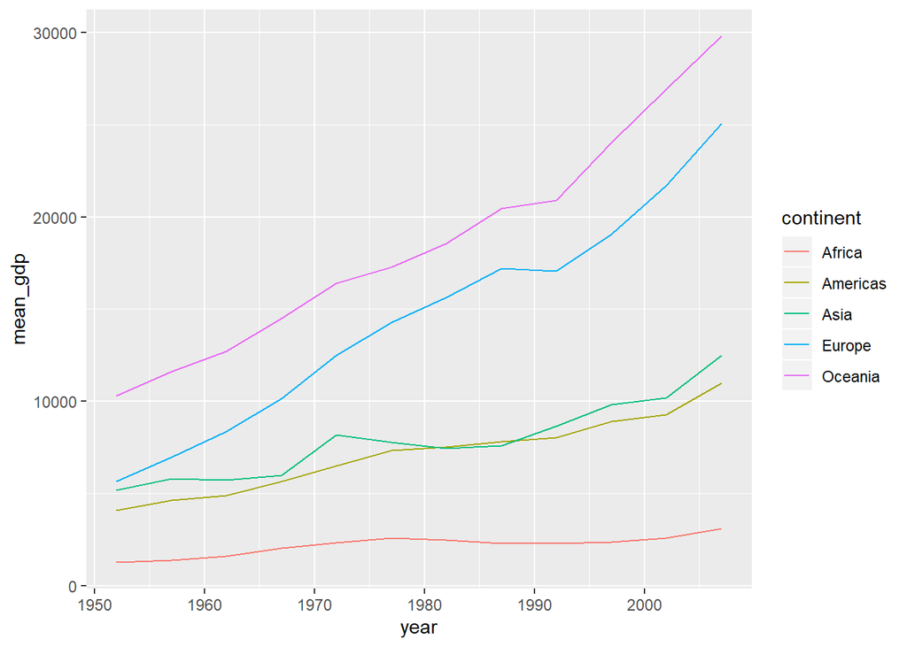

```r
gap_long %>%
  filter(obstype == "gdpPercap") %>%
  group_by(continent, year) %>%
  summarise(mean_gdp = mean(value)) %>%
  ggplot(aes(x = year, y = mean_gdp, color = continent)) +
  geom_line()
```

### From long to wide: `pivot_wider()` (formerly known as `spread()`)

Suppose you now want to look at the relationship between GDP and life expectancy. You will need to spread those observations back out into new columns.

Here’s how we would have done it the old way:

```r
gap_long %>%
  spread(key = "obstype", value = "value")
```

```
## # A tibble: 1,704 x 6
##    continent country  year gdpPercap lifeExp      pop
##    <chr>     <chr>   <int>     <dbl>   <dbl>    <dbl>
##  1 Africa    Algeria  1952     2449.    43.1  9279525
##  2 Africa    Algeria  1957     3014.    45.7 10270856
##  3 Africa    Algeria  1962     2551.    48.3 11000948
##  4 Africa    Algeria  1967     3247.    51.4 12760499
##  5 Africa    Algeria  1972     4183.    54.5 14760787
##  6 Africa    Algeria  1977     4910.    58.0 17152804
##  7 Africa    Algeria  1982     5745.    61.4 20033753
##  8 Africa    Algeria  1987     5681.    65.8 23254956
##  9 Africa    Algeria  1992     5023.    67.7 26298373
## 10 Africa    Algeria  1997     4797.    69.2 29072015
## # ... with 1,694 more rows
```

And here’s the new way:

```r
gap_intermediate <- gap_long %>%
  pivot_wider(names_from = obstype,
              values_from = value)

gap_intermediate
```

```
## # A tibble: 1,704 x 6
##    continent country  year gdpPercap lifeExp      pop
##    <chr>     <chr>   <int>     <dbl>   <dbl>    <dbl>
##  1 Africa    Algeria  1952     2449.    43.1  9279525
##  2 Africa    Algeria  1957     3014.    45.7 10270856
##  3 Africa    Algeria  1962     2551.    48.3 11000948
##  4 Africa    Algeria  1967     3247.    51.4 12760499
##  5 Africa    Algeria  1972     4183.    54.5 14760787
##  6 Africa    Algeria  1977     4910.    58.0 17152804
##  7 Africa    Algeria  1982     5745.    61.4 20033753
##  8 Africa    Algeria  1987     5681.    65.8 23254956
##  9 Africa    Algeria  1992     5023.    67.7 26298373
## 10 Africa    Algeria  1997     4797.    69.2 29072015
## # ... with 1,694 more rows
```

```r
# note that you don't need quotes around obstype and year because they are variables
```

We can now use this intermediate dataframe for plotting.

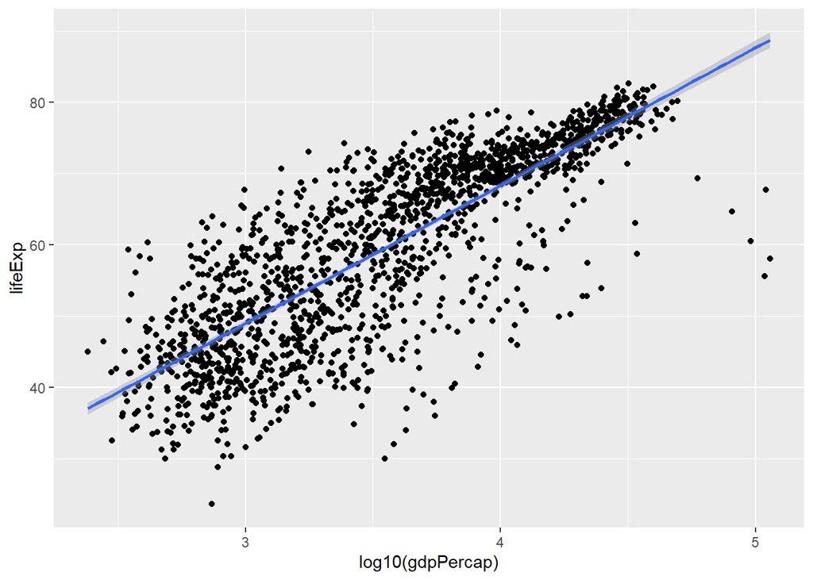

```r
gap_intermediate %>%
  group_by(continent) %>%
  ggplot(aes(x = log10(gdpPercap), y = lifeExp)) +
  geom_point() +
  geom_smooth(method = "lm")
```

If you want to go a step further and pivot the dataframe all the way back to the original wide format:

```r
gap_wide2 <- gap_long %>%
  pivot_wider(names_from = c(obstype, year),
              values_from = value)

gap_wide2
```

```
## # A tibble: 142 x 38
##    continent country gdpPercap_1952 gdpPercap_1957 gdpPercap_1962
##    <chr>     <chr>            <dbl>          <dbl>          <dbl>
##  1 Africa    Algeria          2449.          3014.          2551.
##  2 Africa    Angola           3521.          3828.          4269.
##  3 Africa    Benin            1063.           960.           949.
##  4 Africa    Botswa~           851.           918.           984.
##  5 Africa    Burkin~           543.           617.           723.
##  6 Africa    Burundi           339.           380.           355.
##  7 Africa    Camero~          1173.          1313.          1400.
##  8 Africa    Centra~          1071.          1191.          1193.
##  9 Africa    Chad             1179.          1308.          1390.
## 10 Africa    Comoros          1103.          1211.          1407.
## # ... with 132 more rows, and 33 more variables: gdpPercap_1967 <dbl>,
## #   gdpPercap_1972 <dbl>, gdpPercap_1977 <dbl>, gdpPercap_1982 <dbl>,
## #   gdpPercap_1987 <dbl>, gdpPercap_1992 <dbl>, gdpPercap_1997 <dbl>,
## #   gdpPercap_2002 <dbl>, gdpPercap_2007 <dbl>, lifeExp_1952 <dbl>,
## #   lifeExp_1957 <dbl>, lifeExp_1962 <dbl>, lifeExp_1967 <dbl>,
## #   lifeExp_1972 <dbl>, lifeExp_1977 <dbl>, lifeExp_1982 <dbl>,
## #   lifeExp_1987 <dbl>, lifeExp_1992 <dbl>, lifeExp_1997 <dbl>,
## #   lifeExp_2002 <dbl>, lifeExp_2007 <dbl>, pop_1952 <dbl>,
## #   pop_1957 <dbl>, pop_1962 <dbl>, pop_1967 <dbl>, pop_1972 <dbl>,
## #   pop_1977 <dbl>, pop_1982 <dbl>, pop_1987 <dbl>, pop_1992 <dbl>,
## #   pop_1997 <dbl>, pop_2002 <dbl>, pop_2007 <dbl>
```

Note that `pivot_wider()` automatically separates variable names with an underscore if you have multiple variables in the `names_from =` argument. You can change this as follows:

```r
gap_long %>%
  pivot_wider(names_from = c(obstype, year),
              values_from = value,
              names_sep = ":")
```

```
## # A tibble: 142 x 38
##    continent country `gdpPercap:1952` `gdpPercap:1957` `gdpPercap:1962`
##    <chr>     <chr>              <dbl>            <dbl>            <dbl>
##  1 Africa    Algeria            2449.            3014.            2551.
##  2 Africa    Angola             3521.            3828.            4269.
##  3 Africa    Benin              1063.             960.             949.
##  4 Africa    Botswa~             851.             918.             984.
##  5 Africa    Burkin~             543.             617.             723.
##  6 Africa    Burundi             339.             380.             355.
##  7 Africa    Camero~            1173.            1313.            1400.
##  8 Africa    Centra~            1071.            1191.            1193.
##  9 Africa    Chad               1179.            1308.            1390.
## 10 Africa    Comoros            1103.            1211.            1407.
## # ... with 132 more rows, and 33 more variables: `gdpPercap:1967` <dbl>,
## #   `gdpPercap:1972` <dbl>, `gdpPercap:1977` <dbl>,
## #   `gdpPercap:1982` <dbl>, `gdpPercap:1987` <dbl>,
## #   `gdpPercap:1992` <dbl>, `gdpPercap:1997` <dbl>,
## #   `gdpPercap:2002` <dbl>, `gdpPercap:2007` <dbl>, `lifeExp:1952` <dbl>,
## #   `lifeExp:1957` <dbl>, `lifeExp:1962` <dbl>, `lifeExp:1967` <dbl>,
## #   `lifeExp:1972` <dbl>, `lifeExp:1977` <dbl>, `lifeExp:1982` <dbl>,
## #   `lifeExp:1987` <dbl>, `lifeExp:1992` <dbl>, `lifeExp:1997` <dbl>,
## #   `lifeExp:2002` <dbl>, `lifeExp:2007` <dbl>, `pop:1952` <dbl>,
## #   `pop:1957` <dbl>, `pop:1962` <dbl>, `pop:1967` <dbl>,
## #   `pop:1972` <dbl>, `pop:1977` <dbl>, `pop:1982` <dbl>,
## #   `pop:1987` <dbl>, `pop:1992` <dbl>, `pop:1997` <dbl>,
## #   `pop:2002` <dbl>, `pop:2007` <dbl>
```

### Bonus: Check your dataframe

Here’s a handy way to check whether our widened dataframe (`gap_wide2`) is indeed the same as our original dataframe (`gap_wide`).

```r
all_equal(gap_wide, gap_wide2)
```

```
## [1] TRUE
```

This function lets you know if the number of rows or columns are not the same:

```r
test <- gap_wide2 %>% filter(continent != "Oceania")
all_equal(gap_wide, test)
```

```
## [1] "Different number of rows"
```

```r
test2 <- gap_wide2 %>% select(-gdpPercap_1952)
all_equal(gap_wide, test2)
```

```
## [1] "Cols in x but not y: `gdpPercap_1952`. "
```

### Resources

The official {tidyverse} vignette about pivoting: https://tidyr.tidyverse.org/articles/pivot.html

The original Software Carpentries tutorial: https://swcarpentry.github.io/r-novice-gapminder/14-tidyr/

Great blog post demonstrating pivot_longer() and pivot_wider(): https://www.fromthebottomoftheheap.net/2019/10/25/pivoting-tidily/